# Risk Factor Analysis

## Outcome Variable

**Outcome Variable:** dead

## Predictor Variables

**Intervention Variable:** ever_wasted024_noBW

**Adjustment Set:**

unadjusted

## Stratifying Variables

The analysis was stratified on these variable(s):

- studyid
- country

## Data Summary

| studyid | country | ever_wasted024_noBW | dead | n_cell | n |
| --- | --- | --- | --- | --- | --- |
| ki0047075b-MAL-ED | BANGLADESH | 0 | 0 | 203 | 263 |
| ki0047075b-MAL-ED | BANGLADESH | 0 | 1 | 2 | 263 |
| ki0047075b-MAL-ED | BANGLADESH | 1 | 0 | 58 | 263 |
| ki0047075b-MAL-ED | BANGLADESH | 1 | 1 | 0 | 263 |
| ki0047075b-MAL-ED | INDIA | 0 | 0 | 155 | 246 |
| ki0047075b-MAL-ED | INDIA | 0 | 1 | 2 | 246 |
| ki0047075b-MAL-ED | INDIA | 1 | 0 | 89 | 246 |
| ki0047075b-MAL-ED | INDIA | 1 | 1 | 0 | 246 |
| ki0047075b-MAL-ED | PERU | 0 | 0 | 280 | 302 |
| ki0047075b-MAL-ED | PERU | 0 | 1 | 2 | 302 |
| ki0047075b-MAL-ED | PERU | 1 | 0 | 20 | 302 |
| ki0047075b-MAL-ED | PERU | 1 | 1 | 0 | 302 |
| ki0047075b-MAL-ED | SOUTH AFRICA | 0 | 0 | 264 | 308 |
| ki0047075b-MAL-ED | SOUTH AFRICA | 0 | 1 | 0 | 308 |
| ki0047075b-MAL-ED | SOUTH AFRICA | 1 | 0 | 44 | 308 |
| ki0047075b-MAL-ED | SOUTH AFRICA | 1 | 1 | 0 | 308 |
| ki0047075b-MAL-ED | TANZANIA, UNITED REPUBLIC OF | 0 | 0 | 228 | 261 |
| ki0047075b-MAL-ED | TANZANIA, UNITED REPUBLIC OF | 0 | 1 | 3 | 261 |
| ki0047075b-MAL-ED | TANZANIA, UNITED REPUBLIC OF | 1 | 0 | 30 | 261 |
| ki0047075b-MAL-ED | TANZANIA, UNITED REPUBLIC OF | 1 | 1 | 0 | 261 |
| ki1000304-VITAMIN-A | INDIA | 0 | 0 | 2965 | 3606 |
| ki1000304-VITAMIN-A | INDIA | 0 | 1 | 35 | 3606 |
| ki1000304-VITAMIN-A | INDIA | 1 | 0 | 602 | 3606 |
| ki1000304-VITAMIN-A | INDIA | 1 | 1 | 4 | 3606 |
| ki1000304b-SAS-CompFeed | INDIA | 0 | 0 | 939 | 1502 |
| ki1000304b-SAS-CompFeed | INDIA | 0 | 1 | 20 | 1502 |
| ki1000304b-SAS-CompFeed | INDIA | 1 | 0 | 531 | 1502 |
| ki1000304b-SAS-CompFeed | INDIA | 1 | 1 | 12 | 1502 |
| ki1000304b-SAS-FoodSuppl | INDIA | 0 | 0 | 252 | 397 |
| ki1000304b-SAS-FoodSuppl | INDIA | 0 | 1 | 2 | 397 |
| ki1000304b-SAS-FoodSuppl | INDIA | 1 | 0 | 142 | 397 |
| ki1000304b-SAS-FoodSuppl | INDIA | 1 | 1 | 1 | 397 |
| ki1017093b-PROVIDE | BANGLADESH | 0 | 0 | 560 | 686 |
| ki1017093b-PROVIDE | BANGLADESH | 0 | 1 | 4 | 686 |
| ki1017093b-PROVIDE | BANGLADESH | 1 | 0 | 122 | 686 |
| ki1017093b-PROVIDE | BANGLADESH | 1 | 1 | 0 | 686 |
| ki1066203-TanzaniaChild2 | TANZANIA, UNITED REPUBLIC OF | 0 | 0 | 1909 | 2384 |
| ki1066203-TanzaniaChild2 | TANZANIA, UNITED REPUBLIC OF | 0 | 1 | 1 | 2384 |
| ki1066203-TanzaniaChild2 | TANZANIA, UNITED REPUBLIC OF | 1 | 0 | 474 | 2384 |
| ki1066203-TanzaniaChild2 | TANZANIA, UNITED REPUBLIC OF | 1 | 1 | 0 | 2384 |
| ki1101329-Keneba | GAMBIA | 0 | 0 | 1821 | 2832 |
| ki1101329-Keneba | GAMBIA | 0 | 1 | 43 | 2832 |
| ki1101329-Keneba | GAMBIA | 1 | 0 | 951 | 2832 |
| ki1101329-Keneba | GAMBIA | 1 | 1 | 17 | 2832 |
| ki1112895-Burkina Faso Zn | BURKINA FASO | 0 | 0 | 6128 | 6560 |
| ki1112895-Burkina Faso Zn | BURKINA FASO | 0 | 1 | 26 | 6560 |
| ki1112895-Burkina Faso Zn | BURKINA FASO | 1 | 0 | 400 | 6560 |
| ki1112895-Burkina Faso Zn | BURKINA FASO | 1 | 1 | 6 | 6560 |
| ki1113344-GMS-Nepal | NEPAL | 0 | 0 | 274 | 590 |
| ki1113344-GMS-Nepal | NEPAL | 0 | 1 | 4 | 590 |
| ki1113344-GMS-Nepal | NEPAL | 1 | 0 | 312 | 590 |
| ki1113344-GMS-Nepal | NEPAL | 1 | 1 | 0 | 590 |
| ki1126311-ZVITAMBO | ZIMBABWE | 0 | 0 | 11465 | 13602 |
| ki1126311-ZVITAMBO | ZIMBABWE | 0 | 1 | 782 | 13602 |
| ki1126311-ZVITAMBO | ZIMBABWE | 1 | 0 | 1200 | 13602 |
| ki1126311-ZVITAMBO | ZIMBABWE | 1 | 1 | 155 | 13602 |
| ki1148112-iLiNS-DOSE | MALAWI | 0 | 0 | 1673 | 1844 |
| ki1148112-iLiNS-DOSE | MALAWI | 0 | 1 | 46 | 1844 |
| ki1148112-iLiNS-DOSE | MALAWI | 1 | 0 | 121 | 1844 |
| ki1148112-iLiNS-DOSE | MALAWI | 1 | 1 | 4 | 1844 |
| ki1148112-iLiNS-DYAD-M | MALAWI | 0 | 0 | 1095 | 1188 |
| ki1148112-iLiNS-DYAD-M | MALAWI | 0 | 1 | 29 | 1188 |
| ki1148112-iLiNS-DYAD-M | MALAWI | 1 | 0 | 61 | 1188 |
| ki1148112-iLiNS-DYAD-M | MALAWI | 1 | 1 | 3 | 1188 |
| kiGH5241-JiVitA-3 | BANGLADESH | 0 | 0 | 21592 | 26485 |
| kiGH5241-JiVitA-3 | BANGLADESH | 0 | 1 | 413 | 26485 |
| kiGH5241-JiVitA-3 | BANGLADESH | 1 | 0 | 4410 | 26485 |
| kiGH5241-JiVitA-3 | BANGLADESH | 1 | 1 | 70 | 26485 |
| kiGH5241-JiVitA-4 | BANGLADESH | 0 | 0 | 3971 | 5387 |
| kiGH5241-JiVitA-4 | BANGLADESH | 0 | 1 | 29 | 5387 |
| kiGH5241-JiVitA-4 | BANGLADESH | 1 | 0 | 1376 | 5387 |
| kiGH5241-JiVitA-4 | BANGLADESH | 1 | 1 | 11 | 5387 |

The following strata were considered:

- studyid: ki0047075b-MAL-ED, country: BANGLADESH
- studyid: ki0047075b-MAL-ED, country: INDIA
- studyid: ki0047075b-MAL-ED, country: PERU
- studyid: ki0047075b-MAL-ED, country: SOUTH AFRICA
- studyid: ki0047075b-MAL-ED, country: TANZANIA, UNITED REPUBLIC OF
- studyid: ki1000304-VITAMIN-A, country: INDIA
- studyid: ki1000304b-SAS-CompFeed, country: INDIA
- studyid: ki1000304b-SAS-FoodSuppl, country: INDIA
- studyid: ki1017093b-PROVIDE, country: BANGLADESH
- studyid: ki1066203-TanzaniaChild2, country: TANZANIA, UNITED REPUBLIC OF
- studyid: ki1101329-Keneba, country: GAMBIA
- studyid: ki1112895-Burkina Faso Zn, country: BURKINA FASO
- studyid: ki1113344-GMS-Nepal, country: NEPAL
- studyid: ki1126311-ZVITAMBO, country: ZIMBABWE
- studyid: ki1148112-iLiNS-DOSE, country: MALAWI
- studyid: ki1148112-iLiNS-DYAD-M, country: MALAWI
- studyid: kiGH5241-JiVitA-3, country: BANGLADESH
- studyid: kiGH5241-JiVitA-4, country: BANGLADESH

### Dropped Strata

Some strata were dropped due to rare outcomes:

- studyid: ki0047075b-MAL-ED, country: BANGLADESH
- studyid: ki0047075b-MAL-ED, country: INDIA
- studyid: ki0047075b-MAL-ED, country: PERU
- studyid: ki0047075b-MAL-ED, country: SOUTH AFRICA
- studyid: ki0047075b-MAL-ED, country: TANZANIA, UNITED REPUBLIC OF
- studyid: ki1000304-VITAMIN-A, country: INDIA
- studyid: ki1000304b-SAS-FoodSuppl, country: INDIA
- studyid: ki1017093b-PROVIDE, country: BANGLADESH
- studyid: ki1066203-TanzaniaChild2, country: TANZANIA, UNITED REPUBLIC OF
- studyid: ki1113344-GMS-Nepal, country: NEPAL
- studyid: ki1148112-iLiNS-DOSE, country: MALAWI
- studyid: ki1148112-iLiNS-DYAD-M, country: MALAWI

## Methods Detail

We’re interested in the causal parameters $E[Y_a]$ for all values of $a \in \mathcal{A}$. These parameters represent the mean outcome if, possibly contrary to fact, we intervened to set all units to have $A=a$. Under the randomization and positivity assumptions, these are identified by the statistical parameters $\psi_a=E_W[E_{Y|A,W}(Y|A=a,W)]$. In addition, we’re interested in the mean of $Y$, $E[Y]$ under no intervention (the observed mean). We will estimate these parameters by using SuperLearner to fit the relevant likelihood factors – $E_{Y|A,W}(Y|A=a,W)$ and $p(A=a|W)$, and then updating our likelihood fit using a joint TMLE.

For unadjusted analyses ($W=\{\}$), initial likelihoods were estimated using Lrnr_glm to estimate the simple $E(Y|A)$ and Lrnr_mean to estimate $p(A)$. For adjusted analyses, a small library containing Lrnr_glmnet, Lrnr_xgboost, and Lrnr_mean was used.

Having estimated these parameters, we will then use the delta method to estimate relative risks and attributable risks relative to a prespecified baseline level of $A$.

# Results Detail

## Results Plots

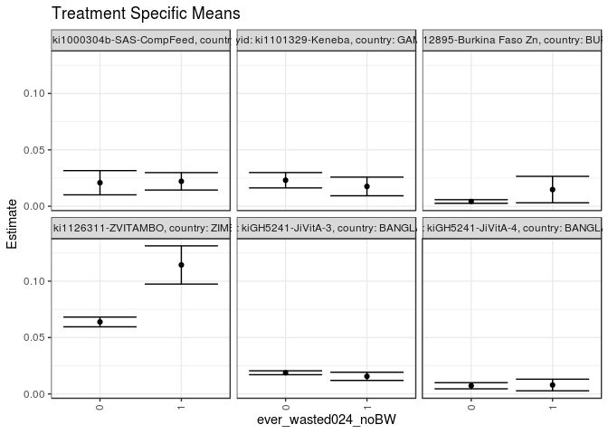

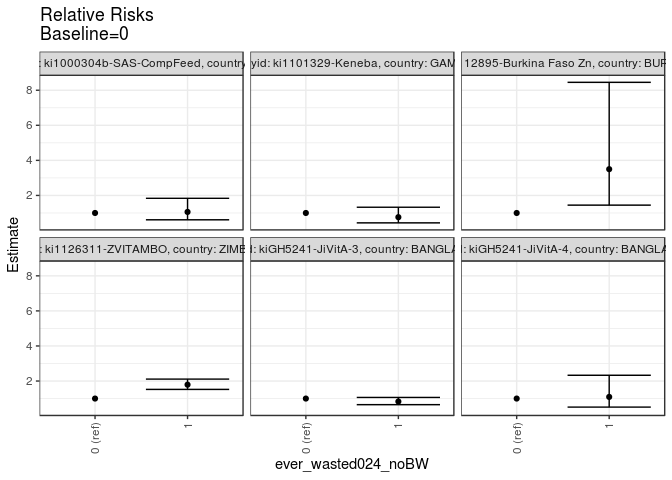

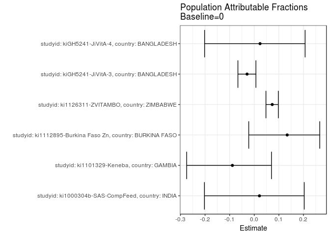

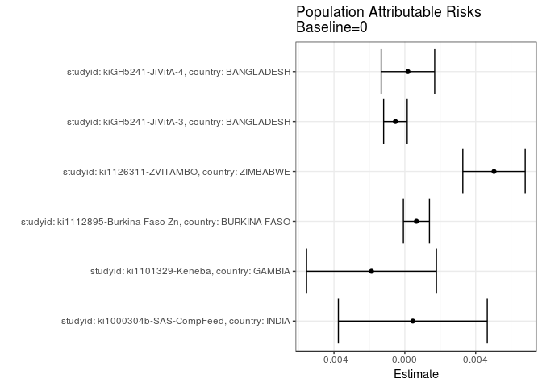

## Results Table

### Parameter: TSM

| studyid | country | intervention_level | baseline_level | estimate | ci_lower | ci_upper |
| --- | --- | --- | --- | --- | --- | --- |
| ki1000304b-SAS-CompFeed | INDIA | 0 | NA | 0.0208551 | 0.0101101 | 0.0316001 |
| ki1000304b-SAS-CompFeed | INDIA | 1 | NA | 0.0220994 | 0.0143717 | 0.0298272 |
| ki1101329-Keneba | GAMBIA | 0 | NA | 0.0230687 | 0.0162524 | 0.0298849 |
| ki1101329-Keneba | GAMBIA | 1 | NA | 0.0175620 | 0.0092859 | 0.0258381 |
| ki1112895-Burkina Faso Zn | BURKINA FASO | 0 | NA | 0.0042249 | 0.0026042 | 0.0058456 |
| ki1112895-Burkina Faso Zn | BURKINA FASO | 1 | NA | 0.0147783 | 0.0030402 | 0.0265164 |
| ki1126311-ZVITAMBO | ZIMBABWE | 0 | NA | 0.0638524 | 0.0595222 | 0.0681826 |
| ki1126311-ZVITAMBO | ZIMBABWE | 1 | NA | 0.1143911 | 0.0974434 | 0.1313389 |
| kiGH5241-JiVitA-3 | BANGLADESH | 0 | NA | 0.0187685 | 0.0170350 | 0.0205019 |
| kiGH5241-JiVitA-3 | BANGLADESH | 1 | NA | 0.0156250 | 0.0119893 | 0.0192607 |
| kiGH5241-JiVitA-4 | BANGLADESH | 0 | NA | 0.0072500 | 0.0045220 | 0.0099780 |
| kiGH5241-JiVitA-4 | BANGLADESH | 1 | NA | 0.0079308 | 0.0027590 | 0.0131026 |

### Parameter: E(Y)

| studyid | country | intervention_level | baseline_level | estimate | ci_lower | ci_upper |
| --- | --- | --- | --- | --- | --- | --- |
| ki1000304b-SAS-CompFeed | INDIA | NA | NA | 0.0213049 | 0.0133015 | 0.0293084 |
| ki1101329-Keneba | GAMBIA | NA | NA | 0.0211864 | 0.0158818 | 0.0264911 |
| ki1112895-Burkina Faso Zn | BURKINA FASO | NA | NA | 0.0048780 | 0.0031919 | 0.0065642 |
| ki1126311-ZVITAMBO | ZIMBABWE | NA | NA | 0.0688869 | 0.0646306 | 0.0731432 |
| kiGH5241-JiVitA-3 | BANGLADESH | NA | NA | 0.0182367 | 0.0166366 | 0.0198369 |
| kiGH5241-JiVitA-4 | BANGLADESH | NA | NA | 0.0074253 | 0.0050095 | 0.0098410 |

### Parameter: RR

| studyid | country | intervention_level | baseline_level | estimate | ci_lower | ci_upper |
| --- | --- | --- | --- | --- | --- | --- |
| ki1000304b-SAS-CompFeed | INDIA | 0 | 0 | 1.0000000 | 1.0000000 | 1.000000 |
| ki1000304b-SAS-CompFeed | INDIA | 1 | 0 | 1.0596685 | 0.6115785 | 1.836064 |
| ki1101329-Keneba | GAMBIA | 0 | 0 | 1.0000000 | 1.0000000 | 1.000000 |
| ki1101329-Keneba | GAMBIA | 1 | 0 | 0.7612916 | 0.4365021 | 1.327748 |
| ki1112895-Burkina Faso Zn | BURKINA FASO | 0 | 0 | 1.0000000 | 1.0000000 | 1.000000 |
| ki1112895-Burkina Faso Zn | BURKINA FASO | 1 | 0 | 3.4979159 | 1.4478946 | 8.450487 |
| ki1126311-ZVITAMBO | ZIMBABWE | 0 | 0 | 1.0000000 | 1.0000000 | 1.000000 |
| ki1126311-ZVITAMBO | ZIMBABWE | 1 | 0 | 1.7914940 | 1.5221299 | 2.108526 |
| kiGH5241-JiVitA-3 | BANGLADESH | 0 | 0 | 1.0000000 | 1.0000000 | 1.000000 |
| kiGH5241-JiVitA-3 | BANGLADESH | 1 | 0 | 0.8325138 | 0.6515962 | 1.063664 |
| kiGH5241-JiVitA-4 | BANGLADESH | 0 | 0 | 1.0000000 | 1.0000000 | 1.000000 |
| kiGH5241-JiVitA-4 | BANGLADESH | 1 | 0 | 1.0939015 | 0.5139347 | 2.328351 |

### Parameter: PAR

| studyid | country | intervention_level | baseline_level | estimate | ci_lower | ci_upper |
| --- | --- | --- | --- | --- | --- | --- |
| ki1000304b-SAS-CompFeed | INDIA | 0 | NA | 0.0004499 | -0.0037536 | 0.0046533 |
| ki1101329-Keneba | GAMBIA | 0 | NA | -0.0018822 | -0.0055483 | 0.0017838 |
| ki1112895-Burkina Faso Zn | BURKINA FASO | 0 | NA | 0.0006532 | -0.0000828 | 0.0013891 |
| ki1126311-ZVITAMBO | ZIMBABWE | 0 | NA | 0.0050346 | 0.0032736 | 0.0067956 |
| kiGH5241-JiVitA-3 | BANGLADESH | 0 | NA | -0.0005317 | -0.0011967 | 0.0001333 |
| kiGH5241-JiVitA-4 | BANGLADESH | 0 | NA | 0.0001753 | -0.0013351 | 0.0016857 |

### Parameter: PAF

| studyid | country | intervention_level | baseline_level | estimate | ci_lower | ci_upper |
| --- | --- | --- | --- | --- | --- | --- |
| ki1000304b-SAS-CompFeed | INDIA | 0 | NA | 0.0211157 | -0.2024922 | 0.2031430 |
| ki1101329-Keneba | GAMBIA | 0 | NA | -0.0888412 | -0.2747831 | 0.0699789 |
| ki1112895-Burkina Faso Zn | BURKINA FASO | 0 | NA | 0.1338967 | -0.0223614 | 0.2662722 |
| ki1126311-ZVITAMBO | ZIMBABWE | 0 | NA | 0.0730843 | 0.0475211 | 0.0979616 |
| kiGH5241-JiVitA-3 | BANGLADESH | 0 | NA | -0.0291567 | -0.0663668 | 0.0067549 |
| kiGH5241-JiVitA-4 | BANGLADESH | 0 | NA | 0.0236062 | -0.2018522 | 0.2067704 |